## Overview

Nowadays you look around and it seems like everyone at the gym or the park is wearing the coloured band of a FitBit, FuelBand, Apple Watch, Jawbone Up or some other activity tracker on their arm. You might very well have one on as you read this. These tools work to collect huge amounts of data about our personal activity, relatively inexpensively and easily. This allows us to quantify how much we do to improve our health by taking measurements of ourselves performing activites such as running, swimming and lifting weights. However, rarely do we try to quantify *how well* we perform an activity.

The Human Activity Recognition Project (HAR) aimed to do just that. After placing accelerometers on the belt, forearm, arm and dumbell of 6 participants they were all asked to perform lifts correctly and incorrectly (using light weights under proper supervision to avoid injury). The goal was to examine how could they determine a reference point for *how well* an exercise is being performed.

By taking the data of the sets of “good” and “bad” workouts we can create tools that can help us stay on track of performing workouts well and safely. The purpose of this project is to create and contrast Machine Learning algorithms using different packages in R to determine these questions. R has many ML libraries available and as such, determining the pros and cons of each is a useful undertaking.

## Loading libraries

So now that the purpose of this project has been outlined as to test packages and contrast the differences between them to determine a reference for proper workout technique, as part of showing my workflow, I’ve loaded up the packages we’ll need first and set a random seed for reproducibility. If anyone wants to have a go these are all the packages that you’ll need.

```r
library(caret)
library(rpart)
library(rpart.plot)
library(randomForest)
library(rattle)
library(e1071)

set.seed(12321)
```

## Data

### Reading

All information surrounding and describing the experiment can be found here: http://groupware.les.inf.puc-rio.br/har. The data can be found at the following Urls and downloaded as shown.

```r
fileUrl1 <- "https://d396qusza40orc.cloudfront.net/predmachlearn/pml-training.csv"
fileUrl2 <- "https://d396qusza40orc.cloudfront.net/predmachlearn/pml-testing.csv"

download.file(fileUrl1, destfile = "./train.csv", method = "curl")
download.file(fileUrl2, destfile = "./test.csv", method = "curl")

train_set <- read.csv("train.csv", header = TRUE, sep = ",", na.strings=c("",NA))
test_set <- read.csv("test.csv", header = TRUE, sep = ",", na.strings=c("",NA))

dim(train_set)
```

```
## [1] 19622   160
```

```r
dim(test_set)
```

```
## [1]  20 160
```

### Pre-processing

The first step in building any Machine Learning problem is to pre-process and clean the data.

```r
df <- data.frame(1)
df2 <- data.frame(1)
count = 1

for(i in 1:ncol(train_set)){
    df[i,] <- (sum(is.na(train_set[,i]))/19622)
      if (df[i,] > 0.9) {
        df2[count,] = i
        count = count + 1
      }
}

count = 0

for(i in 1:nrow(df2)){
  train_set[,(df2[i,]-count)] <- NULL
  test_set[,(df2[i,]-count)] <- NULL
  count = count + 1
  }
```

Finally, since the first 7 columns seem to be for bookkeeping processes only, they too can be dropped.

```r
train_set <- train_set[,-c(1,2,3,4,5,6,7)]
test_set <- test_set[,-c(1,2,3,4,5,6,7)]
```

Voila. Now, with the data fully pre-processed, we can begin to fit and play with some models.

## Building Models

So now that we’re trying to determine an effective model, we can’t very well use our *test* set to build upon. So, to move forward on this we have to partition our *training* data set. Any reasonable partition can be used, I generally like to stick to a 60/40 split.

```r
inTrain <- createDataPartition(train_set$classe, p = 0.6, list = FALSE)
train_model <- train_set[inTrain,]
train_validate <- train_set[-inTrain,]

dim(train_model)
```

```
## [1] 11776    53
```

```r
dim(train_validate)
```

```
## [1] 7846   53
```

We can now begin using the data sets to create our prediction models. To test the packages on effectiveness and efficiency we can set it up to call upon the system time functions to determine how long the models take to train.

### Model 1: Decision Trees

Let’s start building the first model designed with the use of *Decision Trees* for prediction. Decision trees map information and obeservations of variables in a data set to conclusions about the target value, i.e. what classification. It is one of the simpler, more basic forms of Machine Learning however it’s also an extremely useful *visual* tool. *Leaves* are used to show classification while *branches* display a conjunction of features and their strength in the model leading to those conclusions.

A simple tree can be built with the use of the *caret* package calling upon the *rpart* method in *train*.

```r
startTime <- Sys.time()

modFit <- train(classe ~ ., data = train_model, method = "rpart")

runTime <- Sys.time() - startTime
runTime
```

```
## Time difference of 38.73353 secs
```

```r
pred_1 <- predict(modFit, train_validate)
confusionMatrix(pred_1, train_validate$classe)
```

```
## Confusion Matrix and Statistics
##
##           Reference
## Prediction    A    B    C    D    E
##          A 2037  627  677  599  206
##          B   28  385   21  229   90
##          C  163  506  670  458  458
##          D    0    0    0    0    0
##          E    4    0    0    0  688
##
## Overall Statistics
##
##                Accuracy : 0.4818
##                  95% CI : (0.4707, 0.4929)
##     No Information Rate : 0.2845
##     P-Value [Acc > NIR] : < 2.2e-16
##
##                   Kappa : 0.3224
##  Mcnemar's Test P-Value : NA
##
## Statistics by Class:
##
##                      Class: A Class: B Class: C Class: D Class: E
## Sensitivity            0.9126  0.25362  0.48977   0.0000  0.47712
## Specificity            0.6243  0.94185  0.75533   1.0000  0.99938
## Pos Pred Value         0.4913  0.51129  0.29712      NaN  0.99422
## Neg Pred Value         0.9473  0.84027  0.87516   0.8361  0.89460
## Prevalence             0.2845  0.19347  0.17436   0.1639  0.18379
## Detection Rate         0.2596  0.04907  0.08539   0.0000  0.08769
## Detection Prevalence   0.5284  0.09597  0.28741   0.0000  0.08820
## Balanced Accuracy      0.7685  0.59773  0.62255   0.5000  0.73825
```

We can also call upon the rattle package to create the plot of the tree to see the flow.

[figure not shown]

```r
fancyRpartPlot(modFit$finalModel)
```

The results of the confusion matrix aren’t promising and the statistics show this model as very weak with only a *48%* accuracy, with a run time of *38.7 seconds*. This was to be expected since with the amount of variables, it would be hard to accurately fit a tree model. This tool comes from the *caret* package so we can ask, would another package, attempting the same thing, be as effective?

### Model 2: Decision Trees

Another package that can help with decision trees is the standalone *Rpart* package. To call and use the tools, it works very similarly to *train* from the *caret* package.

```r
startTime <- Sys.time()

modFit_rp <- rpart(classe ~ ., data = train_model, method = "class")

runTime <- Sys.time() - startTime
runTime
```

```
## Time difference of 2.049898 secs
```

```r
pred_2 <- predict(modFit_rp, train_validate, type = "class")
confusionMatrix(pred_2, train_validate$classe)
```

```
## Confusion Matrix and Statistics
##
##           Reference
## Prediction    A    B    C    D    E
##          A 1947  173   45   46   53
##          B  114  946  144  170  256
##          C   53  166 1086  157  135
##          D   93  127   92  818   95
##          E   25  106    1   95  903
##
## Overall Statistics
##
##                Accuracy : 0.7265
##                  95% CI : (0.7165, 0.7363)
##     No Information Rate : 0.2845
##     P-Value [Acc > NIR] : < 2.2e-16
##
##                   Kappa : 0.6539
##  Mcnemar's Test P-Value : < 2.2e-16
##
## Statistics by Class:
##
##                      Class: A Class: B Class: C Class: D Class: E
## Sensitivity            0.8723   0.6232   0.7939   0.6361   0.6262
## Specificity            0.9435   0.8919   0.9211   0.9380   0.9646
## Pos Pred Value         0.8600   0.5804   0.6800   0.6678   0.7991
## Neg Pred Value         0.9489   0.9080   0.9549   0.9293   0.9197
## Prevalence             0.2845   0.1935   0.1744   0.1639   0.1838
## Detection Rate         0.2482   0.1206   0.1384   0.1043   0.1151
## Detection Prevalence   0.2886   0.2077   0.2035   0.1561   0.1440
## Balanced Accuracy      0.9079   0.7575   0.8575   0.7870   0.7954
```

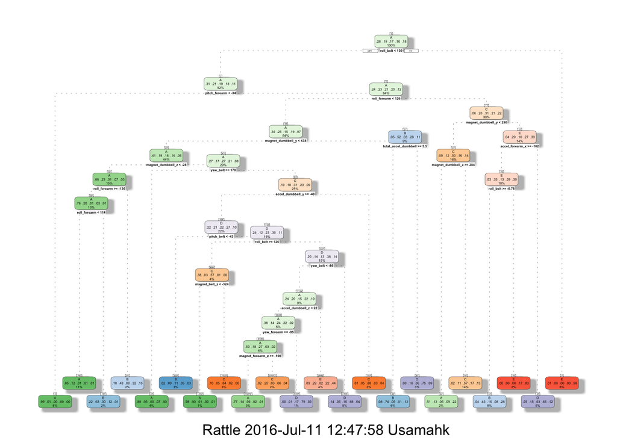

```r
fancyRpartPlot(modFit_rp)
```

Immmediately, we can see that the *Rpart* package seems to be much more effective than the tools included in the *caret* package. The decision tree plot works to classify more effectively and the confusion matrix and statistics show us a *72.6%* accuracy and a runtime of *2.05 seconds* - **extremely** fast.

It would seem that we could stop here as a *72.6%* accuracy, while in need of improvement, can definitely be considered a *good* result. This is quite a clean dataset and as such the perfomance seems a little inflated for a decision tree. Trees don’t have optimal performance when compared to other methods, especially when dealing with other variables so to further enhance this accuracy we can employ the use of other tools such as *bagging*, *boosting* or *Random Forests*.

### Model 3: Random Forests

The next model we can build with *Random Forests* to see if the accuracy can be improved. Random Forests take the decision tree format further by employing the use of a large number of decision trees. Small portions of the data are randomly selected and then key sets of features are decided upon to grow each decision tree. These all give different error rates and the collection of trees (forest) are compared to find a set of variables that are strongest in prediction.

There exists an R package that we can use to create this model; *randomForest*.

```r
startTime <- Sys.time()

modFit_rf <- randomForest(classe ~ ., data = train_model)

runTime <- Sys.time() - startTime
runTime
```

```
## Time difference of 26.86838 secs
```

```r
pred_3 <- predict(modFit_rf, train_validate)
confusionMatrix(pred_3, train_validate$classe)
```

```
## Confusion Matrix and Statistics
##
##           Reference
## Prediction    A    B    C    D    E
##          A 2231   12    0    0    0
##          B    1 1498   16    0    0
##          C    0    8 1350   15    0
##          D    0    0    2 1270    6
##          E    0    0    0    1 1436
##
## Overall Statistics
##
##                Accuracy : 0.9922
##                  95% CI : (0.99, 0.994)
##     No Information Rate : 0.2845
##     P-Value [Acc > NIR] : < 2.2e-16
##
##                   Kappa : 0.9902
##  Mcnemar's Test P-Value : NA
##
## Statistics by Class:
##
##                      Class: A Class: B Class: C Class: D Class: E
## Sensitivity            0.9996   0.9868   0.9868   0.9876   0.9958
## Specificity            0.9979   0.9973   0.9964   0.9988   0.9998
## Pos Pred Value         0.9947   0.9888   0.9832   0.9937   0.9993
## Neg Pred Value         0.9998   0.9968   0.9972   0.9976   0.9991
## Prevalence             0.2845   0.1935   0.1744   0.1639   0.1838
## Detection Rate         0.2843   0.1909   0.1721   0.1619   0.1830
## Detection Prevalence   0.2859   0.1931   0.1750   0.1629   0.1832
## Balanced Accuracy      0.9987   0.9921   0.9916   0.9932   0.9978
```

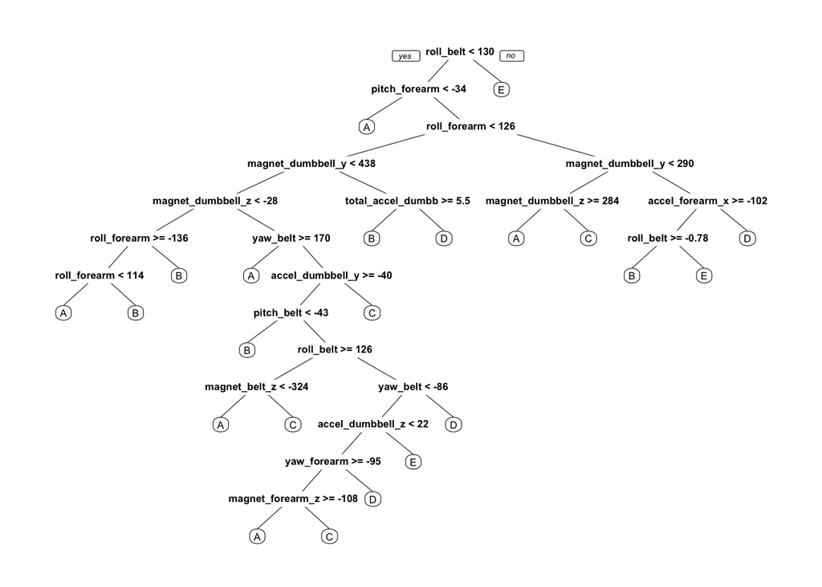

```r
treeModel <- rpart(classe ~ ., data=train_model, method="class")
prp(treeModel)
```

## Prediction using Final Model

At this point we can assume the Random Forest model to be the most accurate to apply to the test set. To further enhance the accuracy (although not necessary) we can train the model to the entire training set and then apply to the test set.

```r
startTime <- Sys.time()

Final_modFit_rf <- randomForest(classe ~ ., data = train_set)

runTime <- Sys.time() - startTime
runTime
```

```
## Time difference of 56.88967 secs
```

As we apply the training over the whole training set the run time is subsequently longer clocking in at *56.9 seconds*. With this complete the last step is to predict on the test set using the Model.

*NOTE - this chunk of code can be used to get an output of the results to check against the correct answers of the test set*

```r
final_pred <- predict(Final_modFit_rf, test_set)

pml_write_files = function(x){
  n = length(x)
  for(i in 1:n){
    filename = paste0("problem_id_",i,".txt")
    write.table(x[i],file=filename,quote=FALSE,row.names=FALSE,col.names=FALSE)
  }
}

pml_write_files(final_pred)
```

By checking our answers, we can find a result of *20/20*. Pretty good work.

## Conclusion

The objective of the project was to examine the data set and apply machine learning techniques to accurately and quantitatively predict how well an exercise is being performed. The data was already split into a training and test set and the training set was used to create a model that could then be applied to the test set to predict the exercise in question. This dataset was quite clean and accurate and we should note that rarely will one with such little pre-processing, high accuracy and little model tuning be available. However, for the purposes of this project, we used this to our advantage to achieve a (more than) satisfactory result.

The three packages all seemed tp have their pros and cons. The *caret* package offers a simple solution yet one with less than an effective result for classification and regression routines.

Using *Rpart* gave us a satisfactory result, one that could have been better, but one with a lightning quick *2.05 seconds* to run. In terms of practicality, the tool seems great used in conjuction with pre-processing of data. At each step of of pre-pro - cutting variables, cleaning them or imputing for missing values - one could easily run a quick model and compare its accuracy relative to each previous iteration. This in turn would be a great indicator of how well a pre-processing strategy is turning out.

However, once a good and clean set of variables are determined, for optimal accuracy, using *Random Forests* would be best since they are miles ahead in effectiveness, while not as speedy.

These are basic Machine Learning techniques. Much more powerful methods, such as Neural Networks, exist and can tackle more complex problems. For classification with small-mid size datasets however, the methods explored above can be perfectly effective.

## Notes and References

The project was begun as part of Coursework for the Coursera Practical Machine Learning Course as part of the Data Science Specialization offered by John’s Hopkins Unversity. It was taken a step further from the original outline with additional packages being explored and contrasted. The data and project overview was provided by http://groupware.les.inf.puc-rio.br/har under a creative commons license for the purposes of learning. Feel free to get in touch if there are errors, questions or concerns you may have regarding my approach or use of the data. I’d be happy to chat about and learn from it!

*Velloso, E.; Bulling, A.; Gellersen, H.; Ugulino, W.; Fuks, H.* **Qualitative Activity Recognition of Weight Lifting Exercises** *. Proceedings of 4th International Conference in Cooperation with SIGCHI (Augmented Human ’13) . Stuttgart, Germany: ACM SIGCHI, 2013.*

Read more:

http://groupware.les.inf.puc-rio.br/har#ixzz4E7hwtjlb

http://www.statmethods.net/advstats/cart.html